# Impact of Company Age, Industry and Covid-19 on Default Rates

## Analysis 2: Default Rates by Industry

The following graph titled “Default Rates by Industry” illustrates the distribution of non-defaulted (blue) and defaulted (red) companies across various sectors, including Agriculture, Construction, Manufacturing, Mining, Other, Retail Trade, Transportation, Utilities, and Wholesale Trade. The x-axis represents these different industries, while the y-axis indicates the count of companies within each sector.

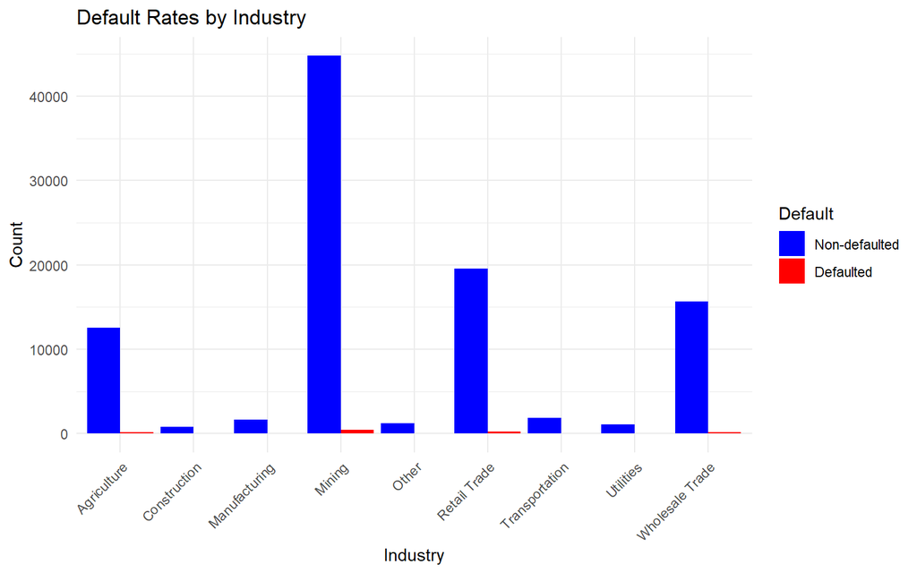

### Defaulted Companies By industries

In order to further dive into the number of defaulted companies by industries,the following graph is made.

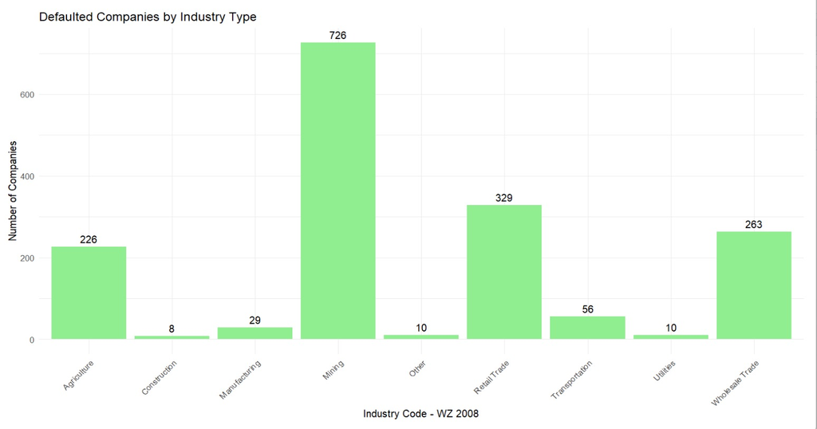

## Analysis 3: Impact of COVID-19 on Default Rates by Industry

This graph is the summary of Pre covid 19 and During covid 19 default rates across every industry.Since This is a summarised version.However,all industries at once makes this analysis difficult.So,Lets analyse further by didviding into into pre covid and During covid,then generating a trend line.

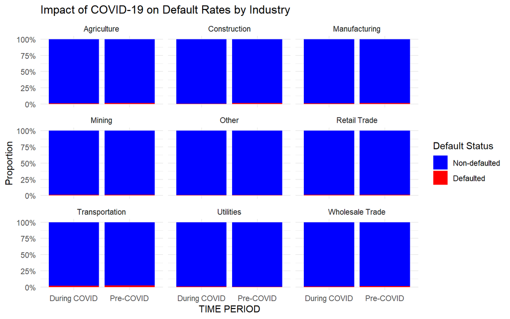

**Histogram for Pre-COVID Period**

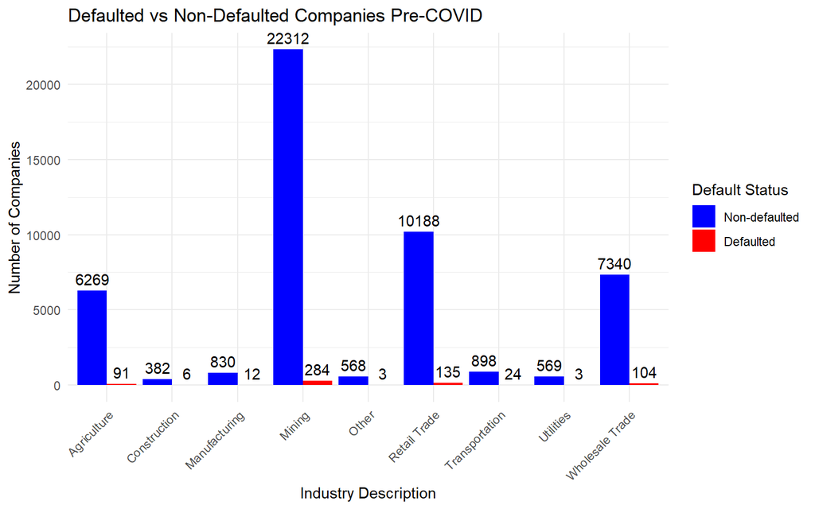

The bar chart titled “Defaulted vs Non-Defaulted Companies Pre-COVID” illustrates the distribution of non-defaulted (blue) and defaulted (red) companies across various industries prior to the COVID-19 pandemic. Key observations indicate that the Mining industry has the highest number of non-defaulted companies at 22,312, with 284 defaults. Retail Trade follows with 10,188 non-defaulted and 135 defaulted companies. The Agriculture sector has 6,269 non-defaulted and 91 defaulted companies. In contrast, Manufacturing has one of the lowest counts with 830 non-defaulted and 12 defaulted companies. The Construction industry has very few defaults (6) compared to its non-defaulted companies (382). Overall, this graph highlights the varying default rates across industries, with Mining and Retail Trade showing the highest non-defaulted counts, while industries like Manufacturing and Construction have relatively fewer defaults, indicating different levels of financial stability and risk profiles pre-COVID.

**Histogram for During-COVID Period**

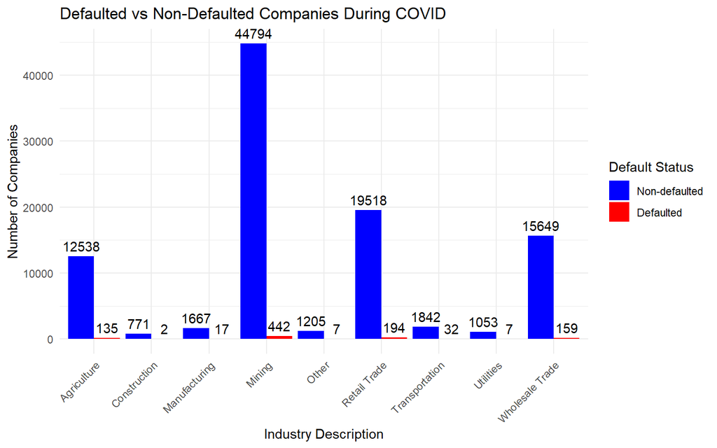

# Trend Line Analysis

The trend analysis shows: X-Axis (Period): Divided into two segments - “Pre-COVID” and “During COVID.” Y-Axis: Count of number of defaulted companies.

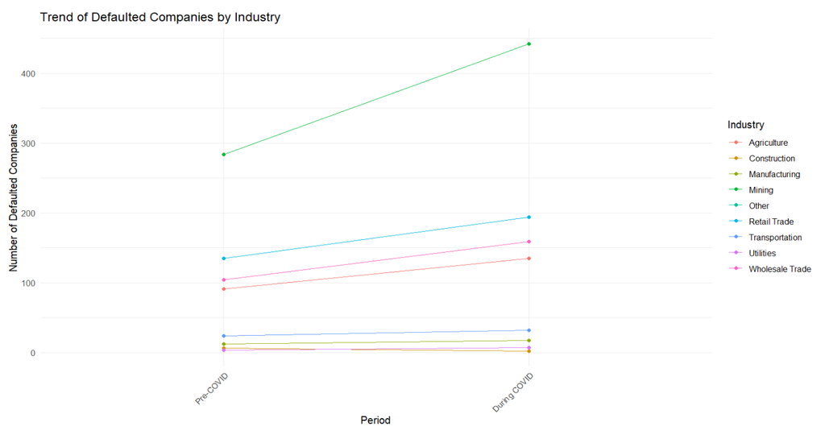

# Conclusion

### Major Findings

The analysis of default rates across various industries during the pre-COVID and during COVID periods reveals several key insights: